# Assignment 7

Use geom_point compare the total vaccines (including all types of vaccines) by date between countries/regions in Asia

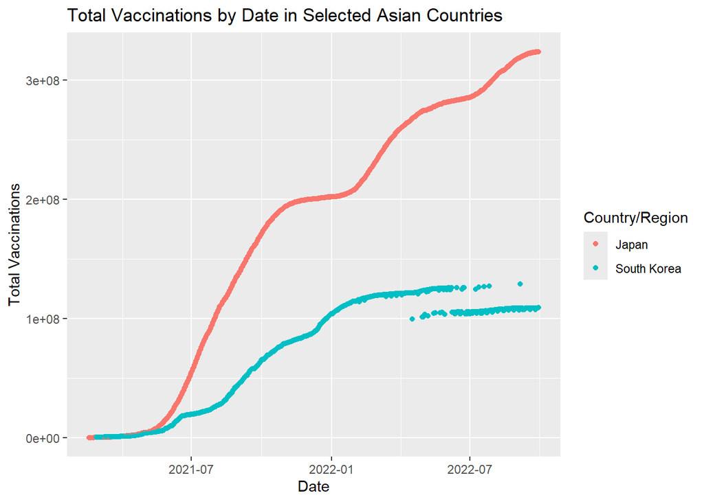

```r
df2 %>%
  filter(location %in% c('China', 'India', 'Japan', 'South Korea', 'Indonesia')) %>%
  group_by(date, location) %>%
  summarise(total_vaccines = sum(total_vaccinations, na.rm = TRUE), .groups = 'drop') %>%
  ggplot() +
  geom_point(mapping = aes(x = date,
                           y = total_vaccines,
                           color = location)) +
  labs(
      title = "Total Vaccinations by Date in Selected Asian Countries",
      x = "Date",
      y = "Total Vaccinations",
      color = "Country/Region"
  )
```

### Both Japan and South Korea increase vaccines as the date progresses. Japan has more vaccines and increases at a faster rate than South Korea.

Use geom_point compare the total vaccines (including all types of vaccines) by date between countries/regions in South America in 2021

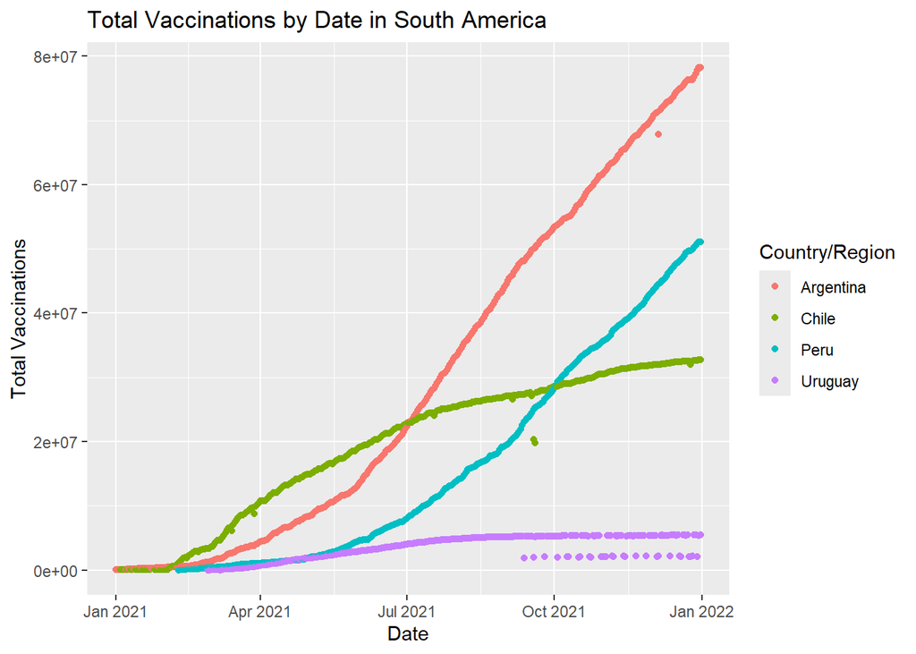

```r
df2 %>%
  filter(location %in% c('Argentina', 'Brazil', 'Chile', 'Colombia', 'Peru', 'Uruguay') &
         year(date) == 2021) %>%
  group_by(date, location) %>%
  summarise(total_vaccines = sum(total_vaccinations, na.rm = TRUE), .groups = 'drop') %>%
  ggplot() +
  geom_point(mapping = aes(x = date,
                           y = total_vaccines,
                           color = location)) +
  labs(
      title = "Total Vaccinations by Date in South America",
      x = "Date",
      y = "Total Vaccinations",
      color = "Country/Region"
  )
```

### Argintina has the most total vaccines. Uruguay has the least and minimal growth with some outliers lower.